# Esercitazione 6

## Istruzioni

Valgono le stesse istruzioni delle esercitazioni precedenti.

Scrivi il programma Python nella cella sotto il testo dell'esercizio (o creane una nuova). Stampa sempre a video il risultato finale per verificare la correttezza dell'esercizio. Talvolta richiamiamo alcuni concetti importanti in una cella di codice sotto il testo dell'esercizio, prova a eseguirla ed eventualmente modificarla per assicurarti di aver capito il necessario.

**Nota.** Alcuni esercizi potrebbero richiedere una semplice risposta a delle domande. In questo caso potete scrivere la soluzione in una cella di tipo "Markdown".

## Consegna

Valgono le regole delle esercitazioni precedenti.

E' obbligatorio **consegnare la soluzione di tutti gli esercizi** (tranne quelli marcati come opzionali) **entro l'inizio della lezione successiva** (in questo caso entro Lunedi' prossimo), nell'apposito assignment su iCorsi. Per consegnare:

- eseguire l'intero notebook partendo da zero (`Kernel -> Restart & Run All`), e controllare che le soluzioni siano quelle attese;
- esportare il notebook in formato html (`File -> Download as...`) e consegnare il file risultante.

Nel caso non abbiate potuto completare uno o piu' esercizi, descrivete il problema incontrato e **consegnate comunque il file con il resto delle soluzioni**.

## Esercizio 1 (da risolvere con carta, penna e semplice calcolatrice)

Ci troviamo in un sottobosco e siamo alla ricerca di funghi da vendere ad un ristorante locale. Noi non siamo esperti di funghi, ma abbiamo acquistato 2 app sofisticate che, data una foto del fungo che abbiamo raccolto, ci dice se il fungo è velenoso o meno. Alla fine della giornata abbiamo raccolto 1000 funghi, e vogliamo analizzarli con le nostre app per scartare quelli velenosi, e portare quelli commestibili al ristorante. La app agisce come un classificatore con due possibili classi: positivo (il test rileva fungo velenoso), negativo (il test rileva fungo commestibile). Sappiamo inoltre, da stime statistiche passate, che il 20% dei funghi che si trovano nel sottobosco dove noi abbiamo raccolto sarà velenoso. In altre parole, 200 dei funghi che abbiamo raccolto sappiamo essere velenosi, ma non sappiamo quali.

Le due app sono state testate prima di essere messe in commercio e per ognuna di esse sono stati ricavati i sequenti indici: APP 1: TPR = 0.98; FPR = 0.15 APP 2: TPR = 0.90; FPR = 0.01

Ricorda: TPR= TP/(TP+FN); FPR= FP/(TN+FP).

## 1.1

Scrivere la matrice di confusione per ognuna delle 2 APP. Hint: Le tabelle di confusione hanno la forma riportata nella cella sotto. Per scrivere la vostra soluzione, potete scrivere le tabelle a mano, fare una foto e trascinarla in una cella di tipo *markdown*. Oppure potete generare la tabella in Excel o LibreOffice e incollarla in una cella di tipo *markdown*.

**Hint**

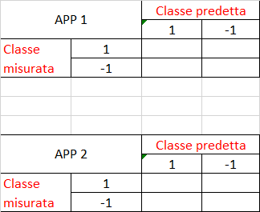

**Solution**

```python
predetto
app1 /neg/pos
neg  /680/120/800
pos  /  4/196/200
tot  /684/316/1000

predetto
app2 /neg/pos
neg  /792/  8/800
pos  / 20/180/200
tot  /812/188/1000
```

### 1.2

Calcolare l'indice di accuratezza di ciascuna app.

L'app con l'indice accuratezza piu' elevato è quella da preferire? (Possibili risposte: Si', No, Non si puo' dire.)

```python
Indice accuratezza: app1 = 0,876 app2 = 0,972
Non si può dire conoscendo solo l'accuratezza
```

**Solution**

### 1.3

Ogni valuazione corretta ha un costo pari a 0, mentre ad ogni valutazione errata è associato un costo positivo. Nello specifico, un fungo commestibile che viene rilevato velenoso ha un costo pari a 5 CHF (è la perdita dovuta al fatto che non avete venduto il fungo al ristorante), mentre un fungo che viene venduto al ristorante come commestibile ma che in reltà è velenoso ha un costo pari a 100 CHF (i vostri funghi non causano decessi, ma causano mal di pancia al cliente. Il costo quantifica quindi una cattiva reputazione che puo' derivare dall'aver venduto al ristorante un fungo velenoso).

Noti questi costi, quale APP preferite usare?

**Solution**

```python
costo app1 = 680*0 + 196*0 + 4*100 + 120*5 = 1000
costo app2 = 792*0 + 180*0 + 20*100 + 8*5 = 2040
dati i costi preferisco utiizzare l'app1
```